# Operaciones con Matrices

Jose A. Aranda y Esteban O. Munguía

Para ingresar una matriz en **R**, se usa la función `matrix()` dentro de ésta debemos indicar los valores que irán dentro de la matriz, el número de filas `nrow=` y columnas `ncol=` y por último, indicar si los valores se acomodarán por filas o por columnas `byrow=`.

Hacemos un objeto **A** que es una matriz que contiene los números del 1 al 9, de 3 filas y 3 columnas: Notar que por *default* los valores se acomodan por columna, en este caso el 1, 2 y 3 son la primera colmuna, el 4, 5 y 6 la segunda y el 7, 8 y 9 la tercera

```r
A<-matrix(1:9,nrow=3,ncol=3)
A
```

```
##      [,1] [,2] [,3]
## [1,]    1    4    7
## [2,]    2    5    8
## [3,]    3    6    9
```

Si queremos que los valores esten acomodados por filas entonces usamos el argumento `byrow=`, que solo puede tener 2 valores: TRUE o FALSE, en este caso sera `byrow=TRUE`.

Notamos que ahora el 1, 2 y 3 es parte de la primera fila, el 4,5 y 6 la segunda y el 7, 8 y 9 la tercera

```r
A<-matrix(1:9,nrow=3,ncol=3,byrow=TRUE)
A
```

```
##      [,1] [,2] [,3]
## [1,]    1    2    3
## [2,]    4    5    6
## [3,]    7    8    9
```

En este ejemplo estamos seguros que **A** es una matriz cuadrada (mismo numero de filas y columnas). Sin embargo, esto lo podemos comprobar con la funcion `dim()`; el resultado de ésta serán dos valores, el primero indica el número de filas del objeto evaluado y el segundo, el número de columnas.

```r
dim(A)
```

```
## [1] 3 3
```

Podemos hacer operaciones con la matriz usando los signos `+ - * /` Si tenemos un objeto con un solo valor y hacemos cualquiera de estas operaciones con la matriz se aplicara la operacion para cada entrada de la matriz, es decir si sumamos A+x se sumara 2 a cada entrada de la matriz:

```r
#suma
x<-2
A+x
```

```
##      [,1] [,2] [,3]
## [1,]    3    4    5
## [2,]    6    7    8
## [3,]    9   10   11
```

```r
#resta
A-x
```

```
##      [,1] [,2] [,3]
## [1,]   -1    0    1
## [2,]    2    3    4
## [3,]    5    6    7
```

```r
#multiplicación
A*x
```

```
##      [,1] [,2] [,3]
## [1,]    2    4    6
## [2,]    8   10   12
## [3,]   14   16   18
```

```r
#división
A/x
```

```
##      [,1] [,2] [,3]
## [1,]  0.5  1.0  1.5
## [2,]  2.0  2.5  3.0
## [3,]  3.5  4.0  4.5
```

Por otro lado, podemos hacer operaciones con matrices. En primer lugar podemos sumar y restar dos matrices siempre que ambas tengan las mismas dimensiones (mismo número de filas y columnas). Los valores de las matrices se suman y se restan uno a uno, con su correspondiente en la entrada de la otra matriz. En este ejemplo el valor a<sub>11</sub> de la matriz **A** se sumará con el elemento b<sub>11</sub> de la matriz **B**, después, el elemento a<sub>12</sub> se suma con el b<sub>12</sub> y así sucesivamente. Debido a lo anterior, el resultado es el mismo si se suma `A+B` que `B+A`.

```r
A<-matrix(c(1,2,2,1),ncol=2,byrow=T)
A
```

```
##      [,1] [,2]
## [1,]    1    2
## [2,]    2    1
```

```r
B<-matrix(c(1,2,3,4),nrow=2,byrow=T)
B
```

```
##      [,1] [,2]
## [1,]    1    2
## [2,]    3    4
```

```r
A+B
```

```
##      [,1] [,2]
## [1,]    2    4
## [2,]    5    5
```

En el ejemplo se multiplica la matriz **A** que es de 2x2 y la matriz **C** de 2x3 (**A** mismo número de columnas que filas en la matriz **C**)

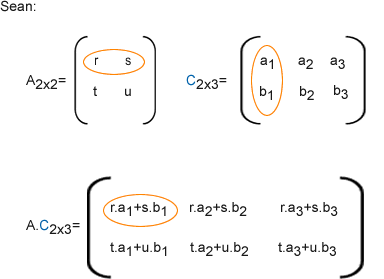

En **R** para indicar que estamos haciendo una multiplicación entre matrices se utiliza el operador `%*%`. Debido a que los resultados provienen de la suma de la multiplicación de filas y columnas, no es lo mismo multiplicar `A*B` que `B*A`:

```r
A<-matrix(c(4,6,
           -1,0),ncol=2, byrow=T)

B<-matrix(c(3,-2,
            4,1),ncol=2, byrow=T)
A%*%B
```

```
##      [,1] [,2]
## [1,]   36   -2
## [2,]   -3    2
```

```r
B%*%A
```

```
##      [,1] [,2]
## [1,]   14   18
## [2,]   15   24
```

```r
C<-matrix(c(3,2,4,
            4,3,5,
            5,6,6),ncol=3, byrow=T)

D<-matrix(c(5,1,1,
            1,7,7,
            4,8,9),ncol=3, byrow=T)
C%*%D
```

```
##      [,1] [,2] [,3]
## [1,]   33   49   53
## [2,]   43   65   70
## [3,]   55   95  101
```

```r
D%*%C
```

```
##      [,1] [,2] [,3]
## [1,]   24   19   31
## [2,]   66   65   81
## [3,]   89   86  110
```

Por último se pueden multiplicar matrices por vectores siempre que se cumpla la regla que el primer elemento tenga el mismo número de columnas que de filas el segundo. En **R** se llaman vectores a un conjunto de valores que pueden ser o no numéricos. Un ejemplo sería el objeto **x** que tiene una secuencia numérica. Este en **R** es un vector, sin embargo cuando le preguntamos cuáles son sus dimensiones, el resultado es `NULL`porque no tiene dimensiones, sólo es un conjunto de números.

```r
x<-c(1,2,3,4,5)
x
```

```
## [1] 1 2 3 4 5
```

```r
dim(x)
```

[output not shown]

En notación matricial un vector es un arreglo numérico unidimensional (que sólo es una fila o una columna). Para indicar a **R** que queremos un vector en el sentido matricial debemos de hacer un objeto de tipo matriz que solo tenga una fila o una columna según sea el caso:

```r
#vector de 3 filas, 1 columna
n<-matrix(c(5,1,4), ncol=1)
n
```

```
##      [,1]
## [1,]    5
## [2,]    1
## [3,]    4
```

```r
dim(n)
```

```
## [1] 3 1
```

```r
A<-matrix(c(3,2,4,
            4,3,5,
            5,6,6), ncol=3,byrow=T)

A%*%n
```

```
##      [,1]
## [1,]   33
## [2,]   43
## [3,]   55
```

```r
#n%*%A
#Error in n %*% A : argumentos no compatibles
```

En este último ejemplo la multiplicación de `A*n`se puede hacer pero la operaciónde `n*A`no se puede porque las dimensiones de este arreglo no son compatibles (el primer elemento no tiene el mismo número de columnas que de filas el segundo).